Skip to contents

# 🐟 Species and countries

Source: [`vignettes/articles/species-countries.Rmd`](https://github.com/Linbojun99/faofishingreport/blob/main/vignettes/articles/species-countries.Rmd)

📦 **Data**: [FAO Global Capture Production](https://www.fao.org/fishery/collection/capture/en), release **2026.1.0** (published by FAO on 2026-03-30; catches 1950–2024), downloaded from Capture_2026.1.0.zip. Licence [CC BY 4.0](https://creativecommons.org/licenses/by/4.0/). `fao_data_info()` shows the release you use and how to cite it.

These functions take the fishing area data of `fishing_area_data()` (here area 27) and look at one species or one country. `country_analysis()` looks at a country in all FAO areas.

```r
FAO27 <- fishing_area_data("Atlantic, Northeast")
```

## 1️⃣ `species_country()`: who catches a species

Names must match the FAO species names exactly; the main species of an area are a good start:

```r
top <- aggregate(Production ~ ASFIS.species..Name., data = FAO27$area_data, FUN = sum)
head(top[order(-top$Production), "ASFIS.species..Name."], 10)
```

```
#>  [1] "Atlantic herring"          "Atlantic cod"
#>  [3] "Capelin"                   "Blue whiting(=Poutassou)"
#>  [5] "Atlantic mackerel"         "Sandeels(=Sandlances) nei"
#>  [7] "European sprat"            "Saithe(=Pollock)"
#>  [9] "Haddock"                   "Norway pout"
```

```r
cod <- species_country(FAO27$area_data, species_name = "Atlantic cod")
```

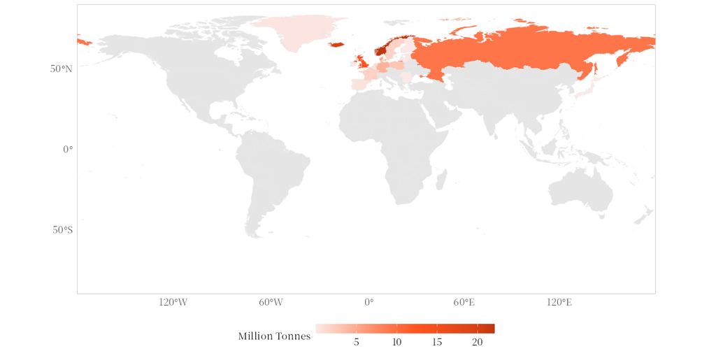

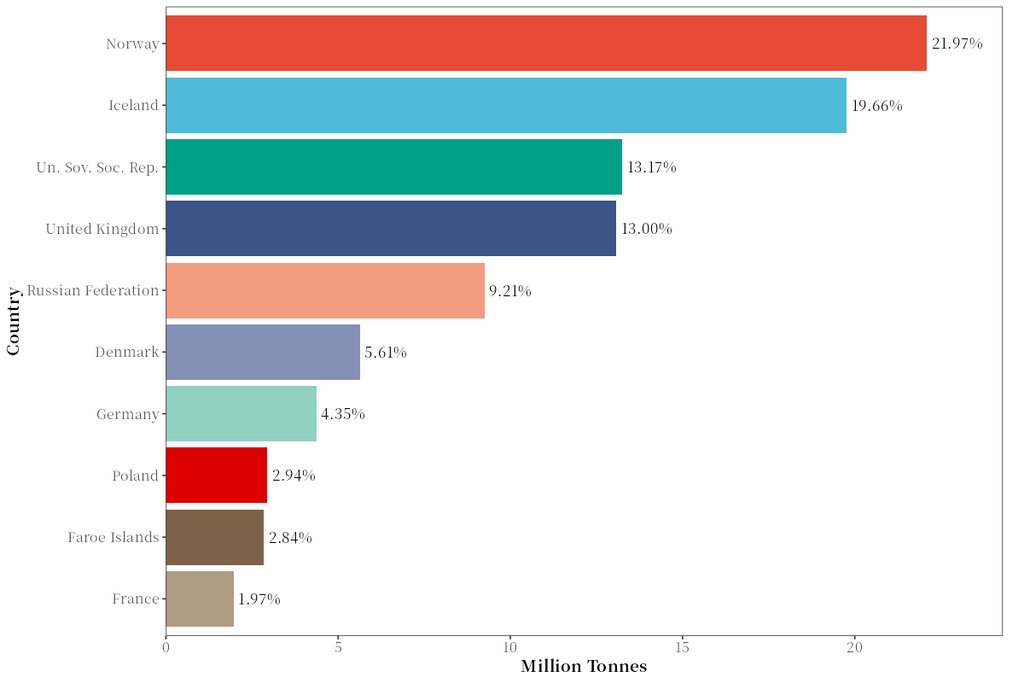

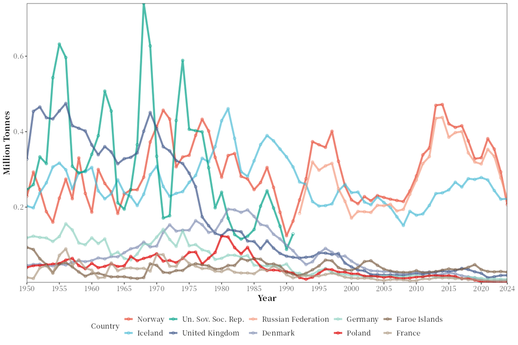

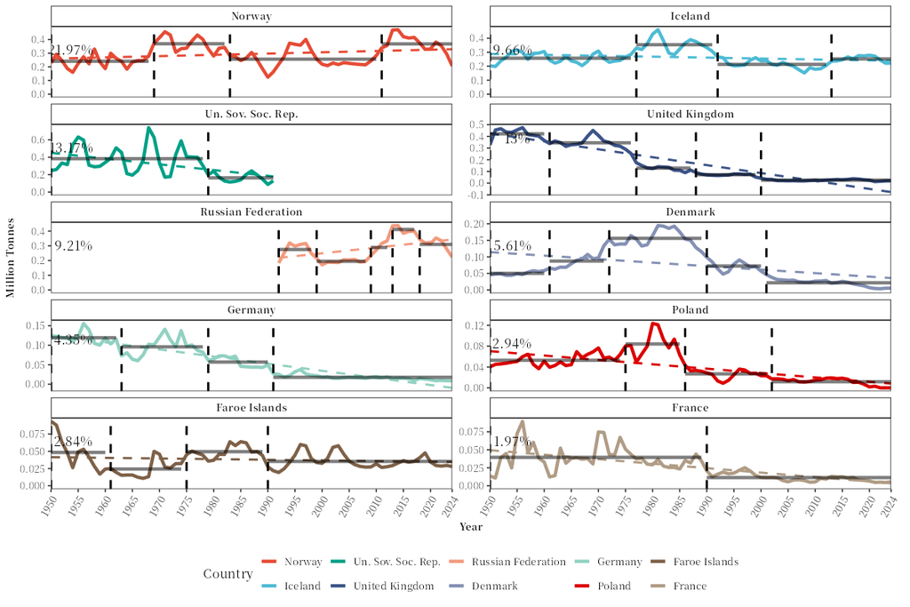

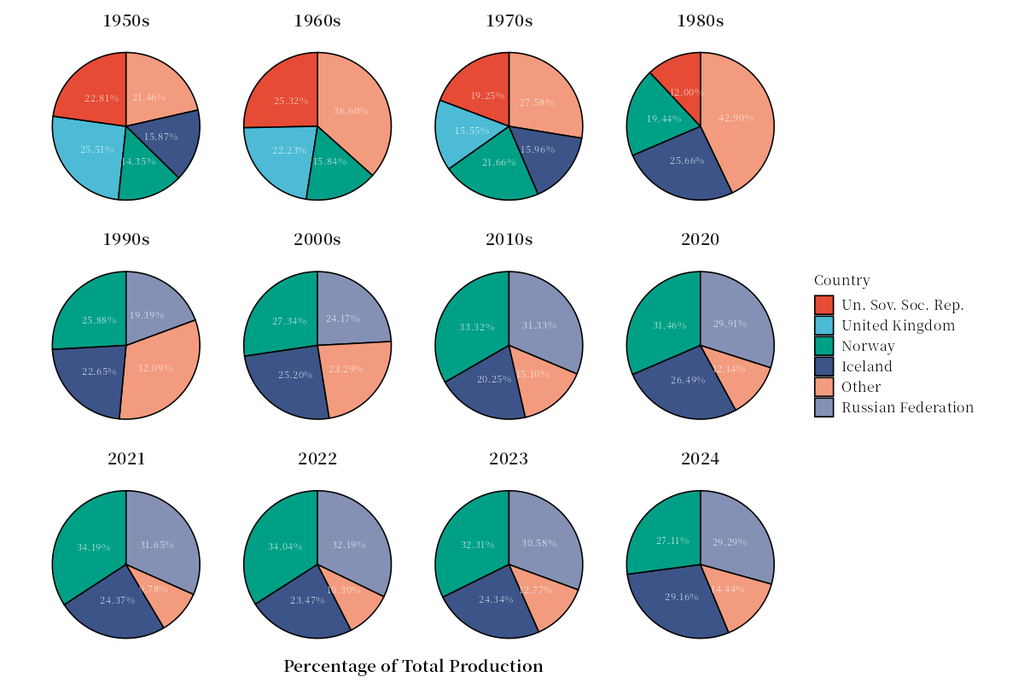

In the file names, `<species>` is the species name with spaces and punctuation replaced by `_` (e.g. `Atlantic_cod`):

| File | Chart |
| --- | --- |
| `<species>_country_map.png` | Catch of the species by country over all years, on a world map |
| `species/<species>_country_ranked_total.png` | Total catch and share of the selected countries (by default the ten main ones) |
| `species/<species>_country_ranked.png` | Their catch over time |
| `species/<species>_country_ranked_wrap.png` | One panel per country, with its share, a linear trend and the breakpoints of its mean catch (with `timeseries_analysis = FALSE`, a smooth curve) |
| `species/<species>_country_pie_selected.png` | Shares of the main countries in each decade and in each year of the current decade (up to four countries, the others are grouped) |

The table `tables/<species>_country_ranked_table.csv` has the average catch per decade, the catch in the last five years and the share of each country in the last year:

```r
table <- read.csv("tables/Atlantic_cod_country_ranked_table.csv",
                  fileEncoding = "UTF-8-BOM", check.names = FALSE)
show_table(table, n = 10, digits = 0)
```

| Country..Name. | 1950s | 1960s | 1970s | 1980s | 1990s | 2000s | 2010s | 2020s | 2020 | 2021 | 2022 | 2023 | 2024 | total_2024_production | percentage_of_total_2024 |
| --- | --- | --- | --- | --- | --- | --- | --- | --- | --- | --- | --- | --- | --- | --- | --- |
| Denmark | 49,390 | 78,840 | 138,487 | 165,392 | 73,986 | 33,334 | 22,034 | 5,230 | 6,996 | 4,448 | 3,654 | 5,440 | 5,610 | 5,610 | 1 |
| Faroe Islands | 50,750 | 20,140 | 38,589 | 51,879 | 36,275 | 38,108 | 34,271 | 29,977 | 34,510 | 29,453 | 28,542 | 29,504 | 27,875 | 27,875 | 4 |
| France | 43,990 | 32,530 | 50,235 | 31,332 | 18,433 | 8,751 | 10,046 | 5,288 | 6,659 | 4,710 | 4,995 | 4,601 | 5,474 | 5,474 | 1 |
| Germany | 121,200 | 89,570 | 103,867 | 57,171 | 28,332 | 17,077 | 15,114 | 9,676 | 11,507 | 9,187 | 9,900 | 9,085 | 8,699 | 8,699 | 1 |
| Iceland | 265,890 | 246,870 | 282,864 | 365,598 | 250,113 | 205,186 | 235,340 | 247,559 | 278,442 | 272,045 | 243,991 | 221,009 | 222,309 | 222,309 | 29 |
| Norway | 240,370 | 255,160 | 383,889 | 277,006 | 285,810 | 222,616 | 387,177 | 313,285 | 330,767 | 381,594 | 353,966 | 293,408 | 206,691 | 206,691 | 27 |
| Poland | 48,440 | 53,090 | 66,401 | 71,149 | 24,222 | 16,289 | 14,938 | 1,069 | 1,800 | 3,164 | 129 | 148 | 104 | 104 | 0 |
| Russian Federation | NA | NA | NA | NA | 214,118 | 196,751 | 364,080 | 300,680 | 314,422 | 353,303 | 334,655 | 277,721 | 223,297 | 223,297 | 29 |
| Un. Sov. Soc. Rep. | 382,090 | 407,780 | 341,246 | 170,941 | 21,676 | NA | NA | NA | NA | NA | NA | NA | NA | NA | NA |
| United Kingdom | 427,430 | 358,120 | 275,555 | 112,584 | 69,885 | 25,002 | 29,324 | 18,373 | 24,762 | 13,001 | 15,645 | 19,051 | 19,404 | 19,404 | 3 |

With `timeseries_analysis = TRUE` the function returns a list of two data frames: the catch of the selected countries by year (`cod[[1]]`) and their breakpoints (`cod[[2]]`: start year, end year and mean catch of each period); with `timeseries_analysis = FALSE`, only the first.

### Options

| Argument | Meaning | Default |
| --- | --- | --- |
| `area_data` | Catch data of an area: `fishing_area_data()$area_data` or any subset of `load_fao_data()` |  |
| `species_name` | FAO species name (ASFIS English name, as in the data) |  |
| `rank_range` | Ranks of the countries shown, by total catch of the species over all years: `1:10` the ten largest, `c(5, 6)` the fifth and the sixth | `1:10` |
| `plot` | Save the charts | `TRUE` |
| `table` | Save the table in `tables/` | `TRUE` |
| `timeseries_analysis` | `TRUE`: panel chart with linear trend and breakpoints; `FALSE`: panel chart with a smooth (loess) curve | `TRUE` |
| `h_value` | Minimum length of a period between breakpoints: a fraction of the series or a number of years | `0.15` |
| `polygon_color` | Colour of the country borders on the map | `"grey90"` |
| `fill_scale` | Palette of the map, any choice of `map_palette` in `fao_settings()` | `NULL`: `map_palette` of `fao_settings()` (`"deep-orange"`) |
| `axis_title_face` | Font face of the axis titles of the map | `"bold"` |
| `axis_title_size_map` | Size of the axis titles of the map | `14` |
| `axis_text_size_map` | Size of the axis labels of the map | `12` |
| `legend_text_size_map` | Size of the legend text of the map | `12` |
| `axis_text_size`, `axis_title_size` | Size of the axis labels and titles of the other charts | `10`, `12` |
| `strip_text_size`, `strip_text_face` | Size and font face of the panel titles | `12`, `"bold"` |
| `ZH` | Older way of asking for Chinese: `TRUE` is `lang = "zh"` | `FALSE` |
| `lang` | Language of the chart text and names: `"en"`, `"zh"` or `"both"` | `NULL`: `"zh"` if `ZH = TRUE`, else the language of `fao_settings()` |
| `pptx` | Also save the charts as editable PowerPoint files | `FALSE`, or `pptx` of `fao_settings()` |
| `plot_show` | Also draw each chart in the plot window (e.g. the Plots pane of RStudio) as it is saved | `FALSE`, or `plot_show` of `fao_settings()` |

In the current version the ranking, time series, panel and pie charts of `species_country()` use fixed text sizes: `axis_text_size`, `axis_title_size`, `strip_text_size` and `strip_text_face` are accepted but do not change them. The map arguments do.

Tuna series are short in some countries; a larger `h_value` gives clearer breakpoints:

```r
species_country(FAO27$area_data, species_name = "Atlantic bluefin tuna", h_value = 5, lang = "zh")
```

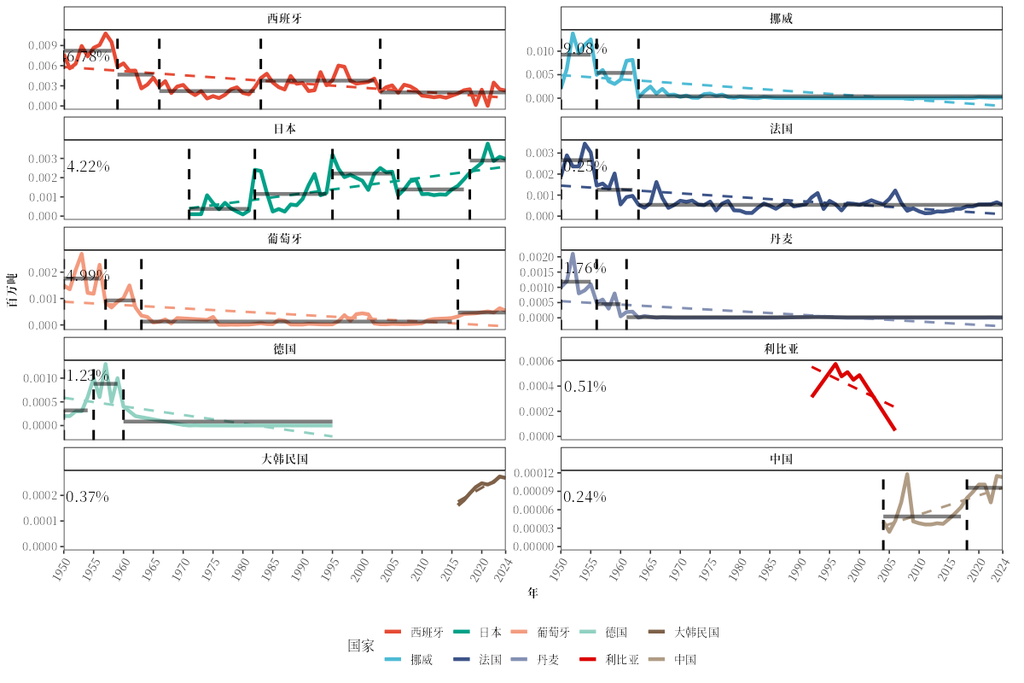

## 2️⃣ `country_species()`: what a country catches in the area

```r
norway <- country_species(FAO27$area_data, country_name = "Norway")
```

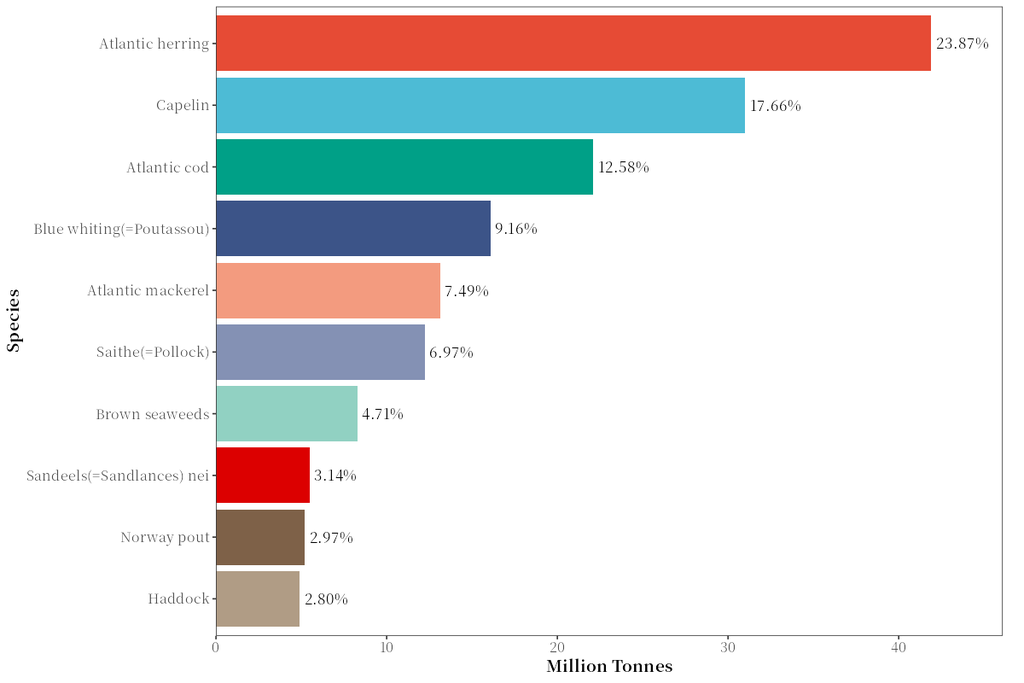

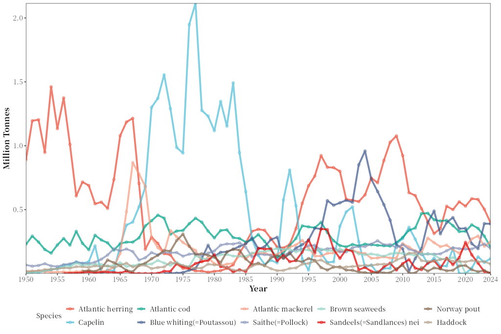

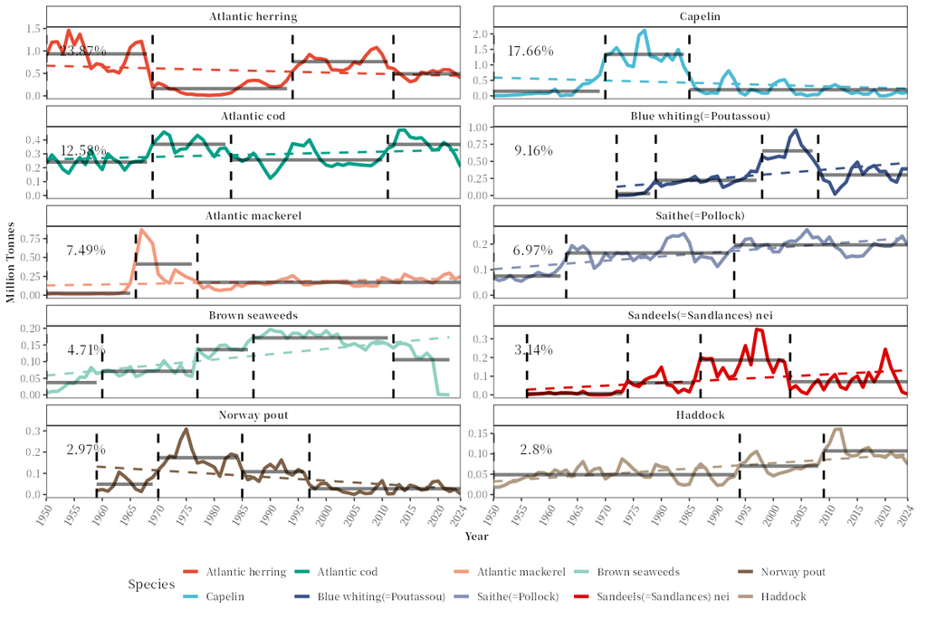

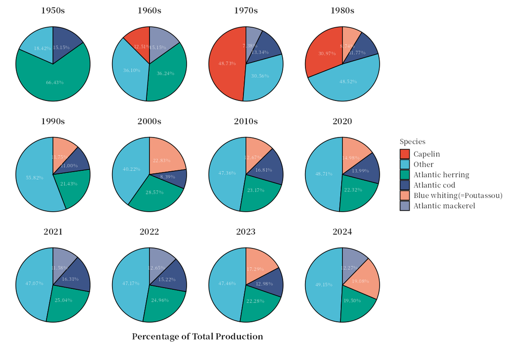

In the file names, `<country>` is the country name with spaces and punctuation replaced by `_`:

| File | Chart |
| --- | --- |
| `country/<country>_species_ranked_total.png` | Total catch and share of the country’s selected species (by default the ten main ones) |
| `country/<country>_species_ranked.png` | Their catch over time |
| `country/<country>_species_ranked_wrap.png` | One panel per species, with share, trend and breakpoints |
| `country/<country>_species_pie_selected.png` | Species shares in each decade and in each year of the current decade |
| `tables/<country>_country_ranked_table.csv` | Average catch per decade, catch in the last five years and share in the last year of each species |

It returns the catch of the selected species by year.

`time_analysis_text_displacement` moves the share labels in the panel chart (years after the first year with catch), useful when they overlap the lines:

```r
country_species(FAO27$area_data, country_name = "Spain", h_value = 5,
                time_analysis_text_displacement = 6, lang = "both")
```

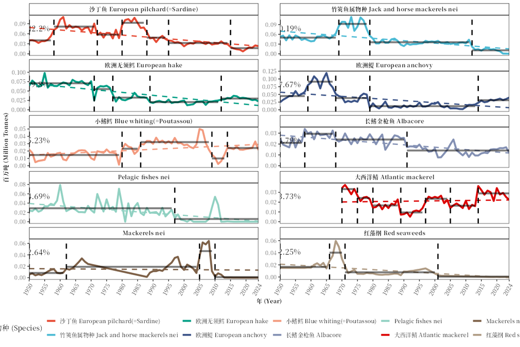

| Argument | Meaning | Default |
| --- | --- | --- |
| `area_data` | Catch data of an area: `fishing_area_data()$area_data` or any subset of `load_fao_data()` |  |
| `country_name` | FAO country name, as in the data |  |
| `rank_range` | Ranks of the species shown, by the country’s total catch over all years: `1:10` the ten largest, `c(5, 6)` the fifth and the sixth | `1:10` |
| `plot` | Save the charts | `TRUE` |
| `table` | Save the table in `tables/` | `TRUE` |
| `timeseries_analysis` | `TRUE`: panel chart with linear trend and breakpoints; `FALSE`: panel chart with a smooth (loess) curve | `TRUE` |
| `time_analysis_text_displacement` | Position of the share labels in the panel chart: number of years after the first year with catch | `10` |
| `h_value` | Minimum length of a period between breakpoints: a fraction of the series or a number of years | `0.15` |
| `ZH` | Older way of asking for Chinese: `TRUE` is `lang = "zh"` | `FALSE` |
| `lang` | Language of the chart text and names: `"en"`, `"zh"` or `"both"` | `NULL`: `"zh"` if `ZH = TRUE`, else the language of `fao_settings()` |
| `pptx` | Also save the charts as editable PowerPoint files | `FALSE`, or `pptx` of `fao_settings()` |
| `plot_show` | Also draw each chart in the plot window (e.g. the Plots pane of RStudio) as it is saved | `FALSE`, or `plot_show` of `fao_settings()` |

## 3️⃣ `country_analysis()`: a country in all FAO areas

`country_analysis()` uses the catch of a country in **all** FAO areas, so it takes the country name only:

```r
norway_global <- country_analysis(country_name = "Norway")
```

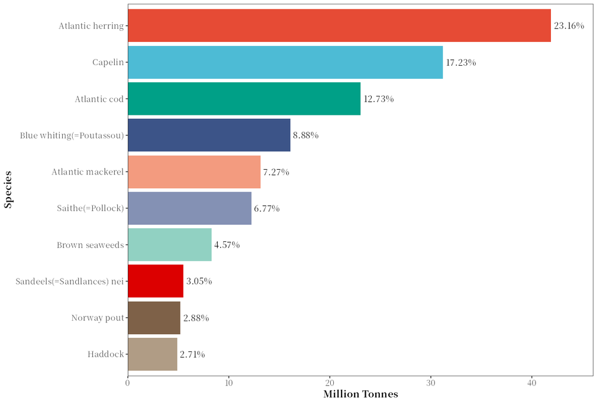

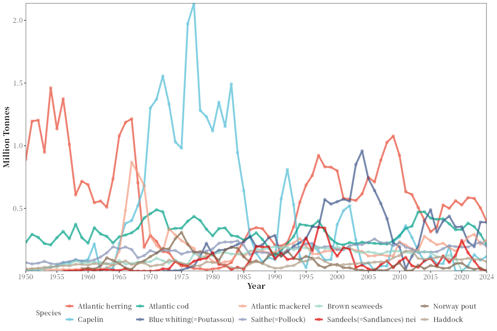

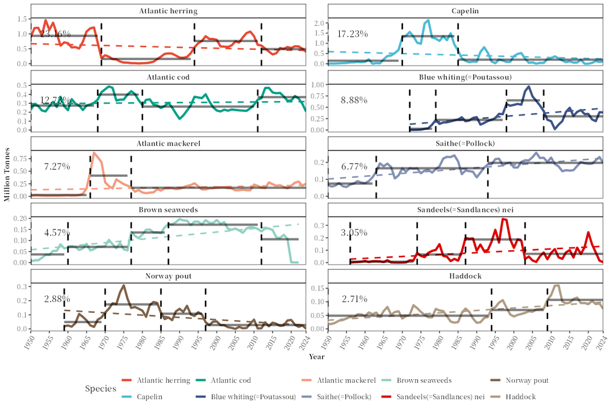

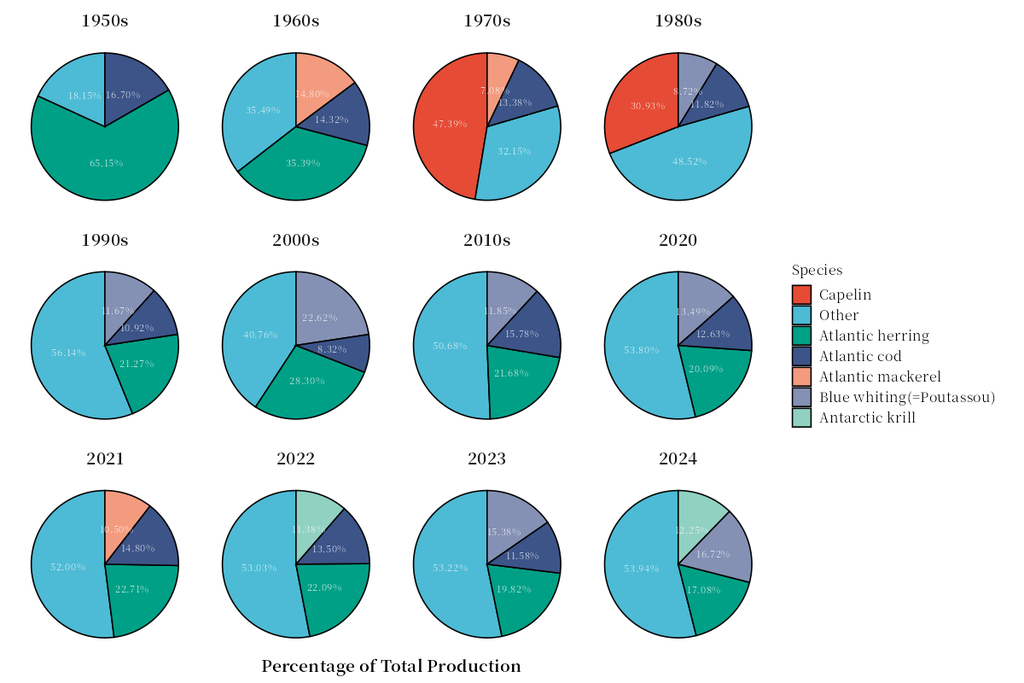

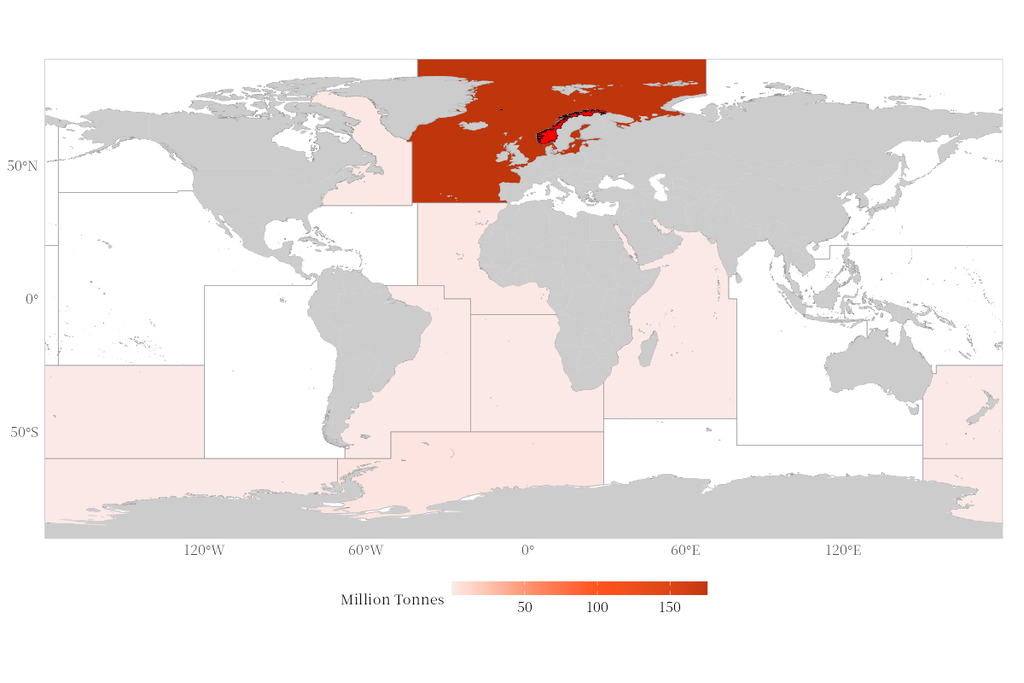

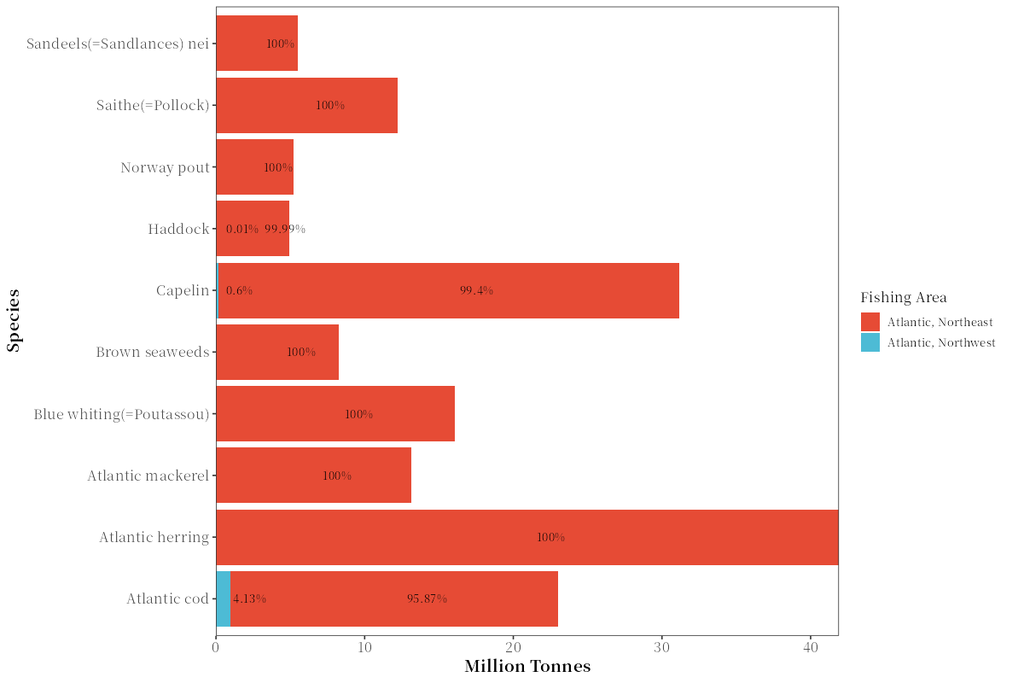

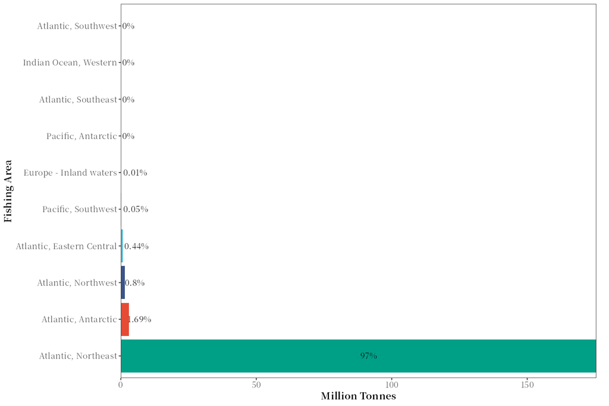

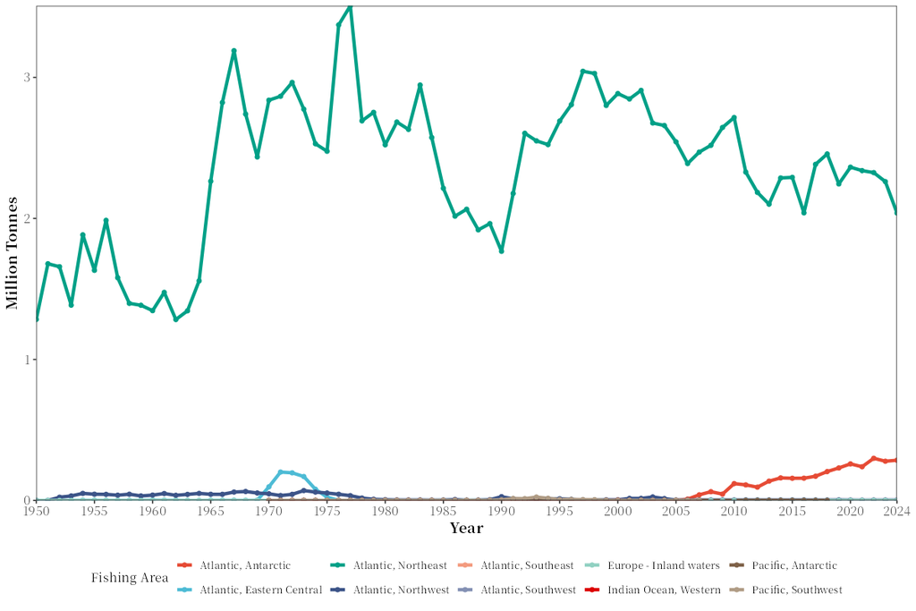

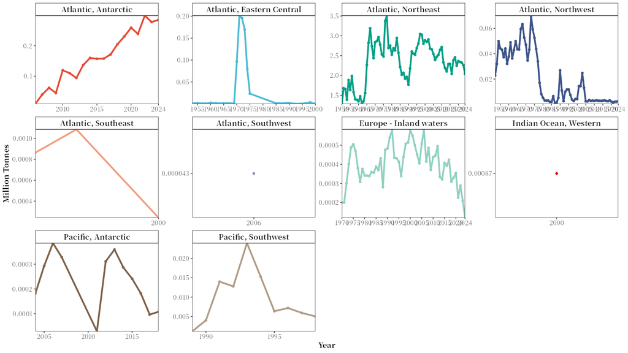

Besides the species charts (as in `country_species()`, file names `<country>analysis_...`), it saves:

| File | Chart |
| --- | --- |
| `country/<country>fishing_area_map.png` | The country’s total catch in each FAO area, on a map of the FAO areas; the country in red |
| `country/<country>analysis_species_by_area.png` | Catch of the main species, split by fishing area, with the share of each area in the species’ catch |
| `country/<country>analysis_area_total_production.png` | Total catch and share by fishing area |
| `country/<country>yearly_area_production.png` | Catch in each area over time |
| `country/<country>yearly_area_production_wrap.png` | One panel per area |
| `tables/<country>analysis_country_ranked_table.csv` | Average catch per decade, catch in the last five years and share in the last year of each species |

It returns the data behind the charts:

```r
names(norway_global)
```

```
#> [1] "country_species_ranked"            "country_species_ranked_coefs_data"
#> [3] "table"                             "country_species_area_total"
#> [5] "country_yearly_area_production"
```

```r
show_table(norway_global$country_species_area_total, n = 8, digits = 1)
```

| ASFIS.species..Name. | FAO.major.fishing.area..Name. | area_species_production | total_species_production | percentage_of_total |
| --- | --- | --- | --- | --- |
| Atlantic herring | Atlantic, Northeast | 41,904,457.7 | 41,904,458 | 100.0 |
| Capelin | Atlantic, Northeast | 30,995,470.2 | 31,182,216 | 99.4 |
| Capelin | Atlantic, Northwest | 186,746.0 | 31,182,216 | 0.6 |
| Atlantic cod | Atlantic, Northeast | 22,086,713.3 | 23,039,382 | 95.9 |
| Atlantic cod | Atlantic, Northwest | 952,668.4 | 23,039,382 | 4.1 |
| Blue whiting(=Poutassou) | Atlantic, Northeast | 16,072,409.4 | 16,072,409 | 100.0 |
| Atlantic mackerel | Atlantic, Northeast | 13,148,795.6 | 13,148,796 | 100.0 |
| Saithe(=Pollock) | Atlantic, Northeast | 12,242,719.4 | 12,242,806 | 100.0 |

| Element | Content |
| --- | --- |
| `country_species_ranked` | Catch of the selected species by year |
| `country_species_ranked_coefs_data` | Their breakpoints |
| `table` | The table saved in `tables/` |
| `country_species_area_total` | Catch of the selected species in each area, and the share of each area in the species’ catch |
| `country_yearly_area_production` | Catch in each area by year, and its share of the country’s catch that year |

| Argument | Meaning | Default |
| --- | --- | --- |
| `country_name` | FAO country name, as in the data |  |
| `rank_range` | Ranks of the species shown, by the country’s total catch over all years: `1:10` the ten largest, `c(5, 6)` the fifth and the sixth | `1:10` |
| `plot` | Save the charts | `TRUE` |
| `table` | Save the table in `tables/` | `TRUE` |
| `timeseries_analysis` | `TRUE`: species panel chart with linear trend and breakpoints; `FALSE`: with a smooth curve | `TRUE` |
| `time_analysis_text_displacement` | Position of the share labels in the panel chart: number of years after the first year with catch | `10` |
| `h_value` | Minimum length of a period between breakpoints: a fraction of the series or a number of years | `0.15` |
| `ZH` | Older way of asking for Chinese: `TRUE` is `lang = "zh"` | `FALSE` |
| `fill_scale` | Palette of the fishing area map, any choice of `map_palette` in `fao_settings()` | `NULL`: `map_palette` of `fao_settings()` |
| `lang` | Language of the chart text and names: `"en"`, `"zh"` or `"both"` | `NULL`: `"zh"` if `ZH = TRUE`, else the language of `fao_settings()` |
| `data_version` | FAO release: `"latest"`, `"bundled"` or a release such as `"2026.1.0"` (see 💾 FAO data) | `"latest"` |
| `pptx` | Also save the charts as editable PowerPoint files | `FALSE`, or `pptx` of `fao_settings()` |
| `plot_show` | Also draw each chart in the plot window (e.g. the Plots pane of RStudio) as it is saved | `FALSE`, or `plot_show` of `fao_settings()` |

The breakpoints are found as described in 🌊 Fishing area analysis (`strucchange::breakpoints()` with a constant mean in each period).

Country names follow FAO: e.g. `"Korea, Republic of"`, `"Russian Federation"`, `"Taiwan Province of China"`. Find them with `grep("Korea", unique(load_fao_data()$Country..Name.), value = TRUE)`.

## 📖 References

Bai, J. and Perron, P. (2003). Computation and analysis of multiple structural change models. *Journal of Applied Econometrics* 18(1): 1–22. [doi:10.1002/jae.659](https://doi.org/10.1002/jae.659)

FAO (2026). FishStat: Global capture production 1950–2024 (release 2026.1.0). In: FishStatJ. https://www.fao.org/fishery/statistics/software/fishstatj/en. Licence: CC-BY-4.0. Release file: https://www.fao.org/fishery/static/Data/Capture_2026.1.0.zip

FAO. *ASFIS List of Species for Fishery Statistics Purposes*. Rome: FAO. https://www.fao.org/fishery/collection/asfis/en

FAO (2024). FAO Major Fishing Areas for Statistical Purposes. In: FAO Fisheries and Aquaculture Division [online]. Licence: CC-BY 4.0. https://www.fao.org/fishery/geonetwork?uuid=ac02a460-da52-11dc-9d70-0017f293bd28 (the area boundaries of the fishing area map, bundled as `inst/extdata/FAO_AREAS_CWP.shp`)

Natural Earth. Admin 0 – Details, map units, 1:50m (the country outlines of the maps). https://www.naturalearthdata.com/downloads/50m-cultural-vectors/50m-admin-0-details/

Pebesma, E. (2018). Simple features for R: standardized support for spatial vector data. *The R Journal* 10(1): 439–446. [doi:10.32614/RJ-2018-009](https://doi.org/10.32614/RJ-2018-009)

Zeileis, A., Kleiber, C., Krämer, W. and Hornik, K. (2003). Testing and dating of structural changes in practice. *Computational Statistics & Data Analysis* 44(1–2): 109–123. doi:10.1016/S0167-9473(03)00030-6

Zeileis, A., Leisch, F., Hornik, K. and Kleiber, C. (2002). strucchange: an R package for testing for structural change in linear regression models. *Journal of Statistical Software* 7(2): 1–38. [doi:10.18637/jss.v007.i02](https://doi.org/10.18637/jss.v007.i02)